# The_Analytics_Edge_edX_MIT15.071x_June2015_3

## Keeping an eye on Healthcare costs_The D2Hawkeye Story_2

### VIDEO 1: THE STORY OF D2HAWKEYE

QUICK QUESTION

In what ways do you think an analytics approach to predicting healthcare cost will improve upon the previous approach of human judgment? Select all that apply.

Ans:It will allow D2Hawkeye to analyze millions of patients.,It will allow D2Hawkeye to make predictions faster than doctors can. , It will allow D2Hawkeye use all available data (millions of cases) to make decisions.

EXPLANATION:All of the above are correct. There are many advantages to having an analytics approach to predict cost. However, it is important that the models are interpretable, so trees are a great model to use in this situation.

### VIDEO 2: CLAIMS DATA

QUICK QUESTION

A common problem in analytics is that you have some data available, but it’s not the ideal dataset. This is the case for this problem, where we only have claims data. Which of the following pieces of information would we ideally like to have in our dataset, but are not included in claims data?

Ans:Blood test results,Physical exam results (weight, height, blood pressure, etc.)

### VIDEO 3: THE VARIABLES

QUICK QUESTION

While we don’t have all of the data we would ideally like to have in this problem (like test results), we can define new variables using the data we do have. Which of the following were new variables defined to help predict healthcare cost? Select all that apply.

Ans:Variables to capture chronic conditions, Noncompliance to treatment, Illness severity,Interactions between illnesses

EXPLANATION:All of these variables were defined using the claims data to improve cost predictions. This shows how the intuition of experts can be used to define new variables and improve the model.

### VIDEO 4: ERROR MEASURES

QUICK QUESTION

The image below shows the penalty error matrix that we discussed in the previous video.

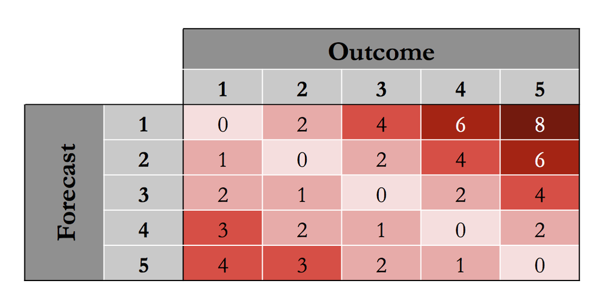

penalty matrix

We can interpret this matrix as follows. Suppose the actual outcome for an observation is 3, and we predict 2. We find 3 on the top of the matrix, and go down to the second row (since we forecasted 2). The penalty error for this mistake is 2. If for another observation we predict (forecast) 4, but the actual outcome is 1, that is a penalty error of 3.

What is the worst mistake we can make, according to the penalty error matrix?

Ans:We predict 1 (very low cost), but the actual outcome is 5 (very high cost).

EXPLANATION:The highest cost is 8, which occurs when the forecast is 1 (very low cost), but the actual cost is 5 (very high cost). It would be much worse for us to ignore an actual high cost observation than to accidentally predict high cost for someone who turns out to be low cost.

What are the “best” types of mistakes we can make, according to the penalty error matrix?

Ans:Mistakes where we predict one cost bucket HIGHER than the actual outcome.

EXPLANATION:We are happier with mistakes where we predict one cost bucket higher than the actual outcome, since this just means we are being a little overly cautious.

### VIDEO 5: CART TO PREDICT COST

QUICK QUESTION

What were the most important factors in the CART trees to predict cost?

Ans:Cost ranges from the previous year

EXPLANATION:The most important variables in a CART tree are at the top of the tree - in this case, they are the cost ranges from the previous year.

*Lets reproduce the the slide notes in brief here as captured in videos 1 to 5 before we proceed for the analysis*

**INTRODUCTION**

The specific exercise we are going to see in this lecture is an analytics approach to building models starting with 2.4 million people over a three year span, the period between 2001 and 2003.

We make out-of-sample predictions for the period of 2003 and 2004.

This was in the early years of D2Hawkeye. Out of the 2.4 million people, we included only people with data for at least 10 months in both periods, both in the observation period and the results period. This decreased the data to 400,000 people.

**The D2 Hawkeye data**

To build an analytics model, let us discuss the variables we used.

- 13,000 diagnoses. It’s for the codes for diagnosis that claims data utilize.
- 22,000 different codes for procedures
- 45,000 codes for prescription drugs.

To work with this massive amount of variables, we aggregated the variables as follows.

To illustrate an example of how we infer further information from the data, the graph here shows on the horizontal axis, time, and on the vertical axis, costs in thousands of dollars.

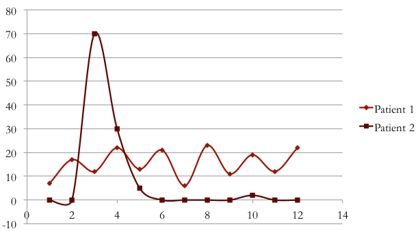

example

- Patient one is a patient who, on a monthly basis, has costs on the order of $10,000 to $15,000, a fairly significant cost but fairly constant in time.
- Patient two has also an annual cost of a similar size to patient one. But in all but the third month, the costs are almost $0. Whereas in the third month, it cost about $70,000.

In fact, this is additional data we defined indicating whether the patient has a *chronic* or an *acute* condition.

In addition to the initial variables we also defined in collaboration with medical doctors, **269 medically-defined rules**.

For example,

- Interaction between various illnesses (*e.g.*, obesity and depression).
- Interaction between diagnosis and age (*e.g.*, more than 65 years old and coronary artery disease).
- Noncompliance with treatment (*e.g.*, non-fulfillment of a particular drug order).
- Illness severity (*e.g.*, severe depression as opposed to regular depression).

There is another set of variables involving **demographic information**, such as gender and age.

An important aspect of the variables are the variables related to cost. Rather than using costs directly, we bucketed costs and considered everyone in the group equally. We defined **five buckets** partitioned in such a way that each accounted for *20% of the total cost*.

The partitions were:

- from 0 to 3,000,
- from 3,000 to 8,000,
- from 8,000 to 19,000,
- from 19,000 to 55,000, and
- above 55,000.

The number of patients that were below 3,000 was 78% of the patients.

**Interpretation of the *cost buckets***

This diagram shows the various levels of risk.

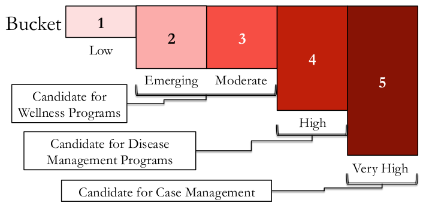

cost buckets

- Bucket one consists of patients that have rather low risk.
- Bucket two has what is called emerging risk.
- In bucket three, moderate level of risk.
- Bucket four, high risk.
- And bucket five, very high risk.

From a medical perspective,

- buckets two and three, the medical and the moderate risk patients, are candidates for *wellness programs*.
- Whereas bucket four, the high risk patients, are candidates for *disease management programs*.
- bucket five, the very high risk patients, are candidates for *case management*.

**Error Measures**

Let us introduce the error measures we used in building the analytics models.

Of course $R^2$ was used, but it was accompanied by other measures.

The so-called **“penalty error”** is motivated by the fact that if you classify a very high-risk patient as a low-risk patient, this is more costly than the reverse, namely classifying a low-risk patient as a very high-risk patient.

Motivated by this, we developed a penalty error with the idea of using asymmetric penalties. The following figure show the *penalty error* as a matrix between outcome and (model) forecast.

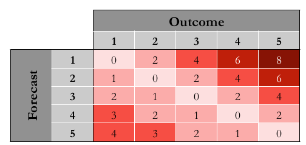

penalty matrix

For example, whenever we classify a low-risk patient as high-risk, we pay a penalty of 2, which is a difference of 3 minus 1, the difference in the error. However, for the reverse case, when you classify a bucket 3 patient as bucket 1 patient, the penalty is twice as much.

The off diagonal penalties are double the corresponding penalties in the lower diagonal.

**Baseline reference**

To judge the quality of the analytics models we developed, we compare it with a baseline, which is to simply predict that the **cost in the next period will be the cost in the current period**.

We have observed that as far as identification of buckets is concerned, the accuracy was 75%.  
The average penalty error of the baseline was 0.56.

**The Method: CART with multi-class classification**

In this case, we use multi-class classification because the outcome to predict is the **bucket classification**, for which there are **five classes**.

Classification trees have the **major advantage of being interpretable** by the physicians who observe them and judge them. In other words, people were able to identify these cases as reasonable.  
The human intuition agreed with the output of the analytics model.

To give you an example, let us consider patients that have two types of diagnosis: coronary artery disease (CAD) and diabetes.

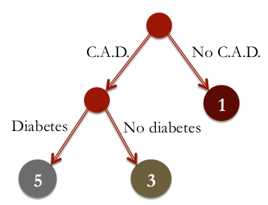

example_tree

- If a patient does not have a coronary artery disease, we would classify the patient as bucket one.
- If it has coronary artery disease, then we check whether the person has diabetes or does not have diabetes.
  - If it has diabetes, then it’s bucket five, very high risk.
  - If it does not have diabetes, but given it has coronary artery disease, it is classified as bucket three.

In the application of Hawkeye, the most important factors in the beginning of the tree were related to cost.  
As the tree grows the secondary factor involve various chronic illnesses and some of the medical rules we discussed earlier.

For example, whether or not the patient has asthma and depression or not. If it has asthma and depression, then it’s bucket five.

**Examples of *bucket 5* patients**

- Under 35 years old, between $3300 and $3900 in claims, C.A.D., but no office visits in last year
- Claims between $3900 and $43000 with at least $8000 paid in last 12 months, $4300 in pharmacy claims, acute cost profile and cancer diagnosis
- More than $58000 in claims, at least $55000 paid in last 12 months, and not an acute profile.

### VIDEO 6: CLAIMS DATA IN R

**LOADING THE DATA**

This data comes from the [DE-SynPUF](http://www.cms.gov/Research-Statistics-Data-and-Systems/Downloadable-Public-Use-Files/SynPUFs/DE_Syn_PUF.html) dataset, published by the United States Centers for Medicare and Medicaid Services (CMS).  
The observations represent a 1% random sample of Medicare beneficiaries, limited to those still alive at the end of 2008.

**The Variables**

Our independent variables are from 2008, and we will be predicting cost in 2009. They are:

- *age*: patient’s age in years at the end of 2008,

and several **binary variables** indicating whether (**1**) or not (**0**) the patient had diagnosis codes for a particular disease or related disorder in 2008:

- **alzheimers**,
- **arthritis**,
- **cancer**,
- **copd**, chronic obstructive pulmonary disease,
- **depression**,
- **diabetes**,
- **heart.failure**,
- **ihd**, ischemic heart disease,
- **kidney disease**,
- **osteoporosis**,
- **stroke**.

Finally there are non-medical-diagnostic variables:

- **reimbursement2008**: the total amount of Medicare reimbursements for this patient in 2008.
- **reimbursement2009**: the total value of all Medicare reimbursements for the patient in 2009.
- **bucket2008**: the cost bucket the patient fell into in 2008,
- **bucket2009**: the cost bucket the patient fell into in 2009.

```r
# VIDEO 6

# Read in the data
Claims <- read.csv("ClaimsData1.csv")
str(Claims)
```

```
## 'data.frame':    458005 obs. of  16 variables:
##  $ age              : int  85 59 67 52 67 68 75 70 67 67 ...
##  $ alzheimers       : int  0 0 0 0 0 0 0 0 0 0 ...
##  $ arthritis        : int  0 0 0 0 0 0 0 0 0 0 ...
##  $ cancer           : int  0 0 0 0 0 0 0 0 0 0 ...
##  $ copd             : int  0 0 0 0 0 0 0 0 0 0 ...
##  $ depression       : int  0 0 0 0 0 0 0 0 0 0 ...
##  $ diabetes         : int  0 0 0 0 0 0 0 0 0 0 ...
##  $ heart.failure    : int  0 0 0 0 0 0 0 0 0 0 ...
##  $ ihd              : int  0 0 0 0 0 0 0 0 0 0 ...
##  $ kidney           : int  0 0 0 0 0 0 0 0 0 0 ...
##  $ osteoporosis     : int  0 0 0 0 0 0 0 0 0 0 ...
##  $ stroke           : int  0 0 0 0 0 0 0 0 0 0 ...
##  $ reimbursement2008: int  0 0 0 0 0 0 0 0 0 0 ...
##  $ bucket2008       : int  1 1 1 1 1 1 1 1 1 1 ...
##  $ reimbursement2009: int  0 0 0 0 0 0 0 0 0 0 ...
##  $ bucket2009       : int  1 1 1 1 1 1 1 1 1 1 ...
```

```r
# Percentage of patients in each cost bucket
#These cost buckets are defined using the thresholds determined by D2Hawkeye.We can verify that the number of patients in each cost bucket has the same structure as what we saw for D2Hawkeye by computing the percentage of patients in each cost bucket.
table(Claims$bucket2009)/nrow(Claims)
```

```
##
##           1           2           3           4           5
## 0.671267781 0.190170413 0.089466272 0.043324855 0.005770679
```

```r
round(100.0*table(Claims$bucket2009)/nrow(Claims), 2)
```

```
##
##     1     2     3     4     5
## 67.13 19.02  8.95  4.33  0.58
```

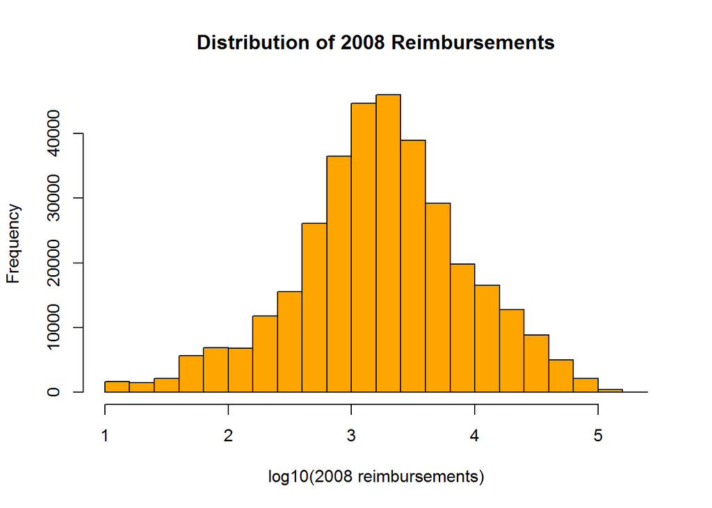

```r
#The vast majority of patients in this data set have low cost.

hist(log10(Claims$reimbursement2008), xlab = "log10(2008 reimbursements)", ylab = "Frequency", main = "Distribution of 2008 Reimbursements", col = "orange")
```

```r
#A MODEL FOR HEALTHCARE COST PREDICTION

#Our goal will be to predict the cost bucket the patient fell into in 2009 using a CART model.

# Split the data
library(caTools)

set.seed(88)

spl = sample.split(Claims$bucket2009, SplitRatio = 0.6) #First we split our entire data set into training and test sets, with 60/40 split:
ClaimsTrain = subset(Claims, spl==TRUE)
ClaimsTest = subset(Claims, spl==FALSE)

summary(ClaimsTrain)
```

```
##       age           alzheimers       arthritis          cancer
##  Min.   : 26.00   Min.   :0.0000   Min.   :0.0000   Min.   :0.00000
##  1st Qu.: 67.00   1st Qu.:0.0000   1st Qu.:0.0000   1st Qu.:0.00000
##  Median : 73.00   Median :0.0000   Median :0.0000   Median :0.00000
##  Mean   : 72.64   Mean   :0.1928   Mean   :0.1546   Mean   :0.06402
##  3rd Qu.: 81.00   3rd Qu.:0.0000   3rd Qu.:0.0000   3rd Qu.:0.00000
##  Max.   :100.00   Max.   :1.0000   Max.   :1.0000   Max.   :1.00000
##       copd          depression        diabetes      heart.failure
##  Min.   :0.0000   Min.   :0.0000   Min.   :0.0000   Min.   :0.0000
##  1st Qu.:0.0000   1st Qu.:0.0000   1st Qu.:0.0000   1st Qu.:0.0000
##  Median :0.0000   Median :0.0000   Median :0.0000   Median :0.0000
##  Mean   :0.1369   Mean   :0.2129   Mean   :0.3809   Mean   :0.2852
##  3rd Qu.:0.0000   3rd Qu.:0.0000   3rd Qu.:1.0000   3rd Qu.:1.0000
##  Max.   :1.0000   Max.   :1.0000   Max.   :1.0000   Max.   :1.0000
##       ihd             kidney        osteoporosis        stroke
##  Min.   :0.0000   Min.   :0.0000   Min.   :0.0000   Min.   :0.00000
##  1st Qu.:0.0000   1st Qu.:0.0000   1st Qu.:0.0000   1st Qu.:0.00000
##  Median :0.0000   Median :0.0000   Median :0.0000   Median :0.00000
##  Mean   :0.4205   Mean   :0.1616   Mean   :0.1738   Mean   :0.04497
##  3rd Qu.:1.0000   3rd Qu.:0.0000   3rd Qu.:0.0000   3rd Qu.:0.00000
##  Max.   :1.0000   Max.   :1.0000   Max.   :1.0000   Max.   :1.00000
##  reimbursement2008   bucket2008    reimbursement2009   bucket2009
##  Min.   :     0    Min.   :1.000   Min.   :     0    Min.   :1.000
##  1st Qu.:     0    1st Qu.:1.000   1st Qu.:   130    1st Qu.:1.000
##  Median :   960    Median :1.000   Median :  1540    Median :1.000
##  Mean   :  4016    Mean   :1.438   Mean   :  4280    Mean   :1.522
##  3rd Qu.:  3110    3rd Qu.:2.000   3rd Qu.:  4220    3rd Qu.:2.000
##  Max.   :194910    Max.   :5.000   Max.   :158800    Max.   :5.000
```

```r
#QUICK QUESTION

#What is the average age of patients in the training set, ClaimsTrain?
mean(ClaimsTrain$age)
```

```
## [1] 72.63773
```

```r
#Ans:72.63773  #or by looking at summary(ClaimsTrain),The mean age should be listed under the age variable
#What proportion of people in the training set (ClaimsTrain) had at least one diagnosis code for diabetes?
prop.table(table(ClaimsTrain$diabetes)) #or table(ClaimsTrain$diabetes)/nrow(ClaimsTrain)
```

```
##
##         0         1
## 0.6191017 0.3808983
```

```r
#Ans:0.3808983
#since diabetes is a binary variable, the mean value of diabetes gives the proportion of people with at least one diagnosis code for diabetes.
```

### VIDEO 7: BASELINE METHOD AND PENALTY MATRIX

The baseline method would predict that the cost bucket for a patient in 2009 will be the same as it was in 2008.  
So let’s create a classification matrix to compute the accuracy for the baseline method on the test set.

The accuracy is the sum of the diagonal, the observations that were classified correctly, divided by the total number of observations in our test set.

```r
# VIDEO 7

# Baseline method
cmat_base <- table(ClaimsTest$bucket2009, ClaimsTest$bucket2008)
cmat_base
```

```
##
##          1      2      3      4      5
##   1 110138   7787   3427   1452    174
##   2  16000  10721   4629   2931    559
##   3   7006   4629   2774   1621    360
##   4   2688   1943   1415   1539    352
##   5    293    191    160    309    104
```

```r
base_accu <- sum(diag(cmat_base))/nrow(ClaimsTest)
base_accu  #(110138 + 10721 + 2774 + 1539 + 104)/nrow(ClaimsTest)
```

```
## [1] 0.6838135
```

```r
#The accuracy of the baseline method is the 68.38%

#How about the penalty error?
#We need to first create a penalty matrix, where we will put the actual outcomes on the left (rows), and the predicted outcomes on the top (columns) (note that this is the transpose of the matrix shown in the figure above).

# Penalty Matrix
PenaltyMatrix = matrix(c(0,1,2,3,4,2,0,1,2,3,4,2,0,1,2,6,4,2,0,1,8,6,4,2,0), byrow=TRUE, nrow=5)

PenaltyMatrix
```

```
##      [,1] [,2] [,3] [,4] [,5]
## [1,]    0    1    2    3    4
## [2,]    2    0    1    2    3
## [3,]    4    2    0    1    2
## [4,]    6    4    2    0    1
## [5,]    8    6    4    2    0
```

```r
# Penalty Error of Baseline Method
as.matrix(table(ClaimsTest$bucket2009, ClaimsTest$bucket2008))*PenaltyMatrix
```

```
##
##         1     2     3     4     5
##   1     0  7787  6854  4356   696
##   2 32000     0  4629  5862  1677
##   3 28024  9258     0  1621   720
##   4 16128  7772  2830     0   352
##   5  2344  1146   640   618     0
```

```r
sum(as.matrix(table(ClaimsTest$bucket2009,ClaimsTest$bucket2008))*PenaltyMatrix)/nrow(ClaimsTest)
```

```
## [1] 0.7386055
```

```r
#The penalty error of the baseline method is 0.739.

#Our goal will be to create a CART model that has an accuracy higher than 68.38% and a penalty error lower than 0.739.

#QUICK QUESTION

#Suppose that instead of the baseline method discussed in the previous video, we used the baseline method of predicting the most frequent outcome for all observations. This new baseline method would predict cost bucket 1 for everyone.

#The confusion matrix would be the following:
 #or

cmat_all1 <- matrix(c(rowSums(cmat_base), rep(0, 20)), byrow = FALSE, nrow = 5)
cmat_all1
```

```
##        [,1] [,2] [,3] [,4] [,5]
## [1,] 122978    0    0    0    0
## [2,]  34840    0    0    0    0
## [3,]  16390    0    0    0    0
## [4,]   7937    0    0    0    0
## [5,]   1057    0    0    0    0
```

```r
#What would the accuracy of this baseline method be on the test set?
#Accuracy:
sum(cmat_all1[,1])
```

```
## [1] 183202
```

```r
accu_base_all_1 <- cmat_all1[1,1]/nrow(ClaimsTest)
accu_base_all_1
```

```
## [1] 0.67127
```

```r
#or
prop.table(table(ClaimsTest$bucket2009))[1]
```

```
##       1
## 0.67127
```

```r
#Ans:0.67127

#What would the penalty error of this baseline method be on the test set?
# as.matrix(cmat_all1*PenaltyMatrix)
# sum(as.matrix(cmat_all1*PenaltyMatrix))
altbase_penalty_error <- sum(as.matrix(cmat_all1*PenaltyMatrix))/nrow(ClaimsTest)
altbase_penalty_error
```

```
## [1] 1.044301
```

```r
#Ans:1.044301
##For the penalty error, since this baseline method predicts 1 for all observations, it would have a penalty error of:(0*122978 + 2*34840 + 4*16390 + 6*7937 + 8*1057)/nrow(ClaimsTest) = 1.044301
```